# Tommaso Biganzoli

Final Assignement

2024-02-28

### Data representation

The following dataset represent PGA Tour’s golf Players Stats of 2021/2022 season, taken from [https://www.pgatour.com/stats.html], which is the official website of PGA Tour. The PGA Tour is an organization that runs the leading professional golf tours in the United States. The study is done by all the coaches of the PGA Tour, to improve the playing conditions of their player, with the main objective of improving their game, and then to increase their earnings, For this you research what are the factors that affect the most seasonal earnings of a player. Here is an article with the example of player Scott Stallings. [https://www.golfdigest.com/story/why-a-little-stat-analysis-goes-a-long-way-on-the-pga-tour]. I decided to center all my data to its mean value, in order to overcome the discrepancy in the units of measurement.

```r
str(PGATour)
```

```
## tibble [63 × 13] (S3: tbl_df/tbl/data.frame)
##  $ Name           : chr [1:63] "Ted Potter" "Sungjae Im" "Adam Schenk" "K.H. Lee" ...
##  $ Rounds         : num [1:63] 29.9 28.9 11.9 11.9 10.9 ...
##  $ Strks          : num [1:63] 0.4688 0.0258 -0.1532 -0.2772 -0.0662 ...
##  $ ScoreAVG       : num [1:63] 1.302 -0.976 0.38 -0.16 -1.445 ...
##  $ Sponsor        : chr [1:63] "Titleist" "Titleist" "Callaway" "Taylormade" ...
##  $ GIR            : num [1:63] -8.923 2.157 0.447 -2.663 1.157 ...
##  $ GreensHIT      : num [1:63] -489.3 402.7 122.7 111.7 86.7 ...
##  $ Earnings       : num [1:63] -673172 3273581 -954870 1052787 11752517 ...
##  $ RelPar         : num [1:63] 1.48997 -0.04403 -0.00403 -0.02403 -0.06403 ...
##  $ AVGPutting     : num [1:63] -0.146 0.154 -0.146 -0.446 -0.146 ...
##  $ DrivAccuracy   : num [1:63] 0.543 4.493 -4.767 1.133 -1.047 ...
##  $ Country        : chr [1:63] "Other" "Other" "USA" "Other" ...
##  $ AVGDrivDistance: num [1:63] -19.9 3.8 4.1 2.6 11.7 ...
```

###### Variables

*Name* : Player Name *Rounds* : Total rounds played for each player (4*number of tournaments made).* Strks* : Average Value Per Tournament for Strokes Gain on Approach (negative: I lost strokes on my short game in comparison to all other players). *ScoreAVG* : Score average, calculated as sum of the results/ # of rounds *GIR* : Percentage of Greens Hit in Regulation (GIR, How many Greens in % I hit for each tournament I play). *GreensHIT* : total # of greens hit in the regular season. *RelPar* : Score relative to par per GIR (For each Green Hit per Tournament, the average of the difference between par and my final score). *AVGPutting* : Average distance for birdie putt made (how long was my birdie putt, given the fact I made birdie). *Sponsor* : Sponsor (which golf equipment they use (Titleist Taylormade or Callaway)), this is a categorical predictor. *Earnings* : How many dollars they earn in the 2021 season. *DrivAccuracy* : probability of taking the farway whenever using the drive from the tee, calculated as # farway taken / # farway total. *Country* : country country from where they come. *AVGDrivDistance* : Average of the meters made by the tee with the drive. Calculated as Total meters made by tee with drive/ number of rounds.

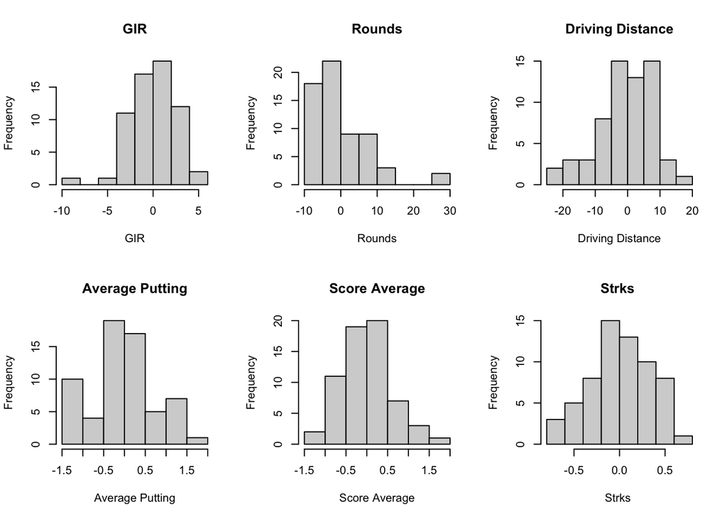

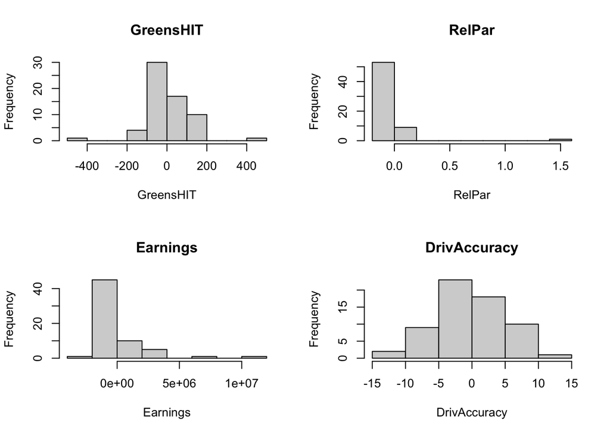

##### Correlation among all the variables

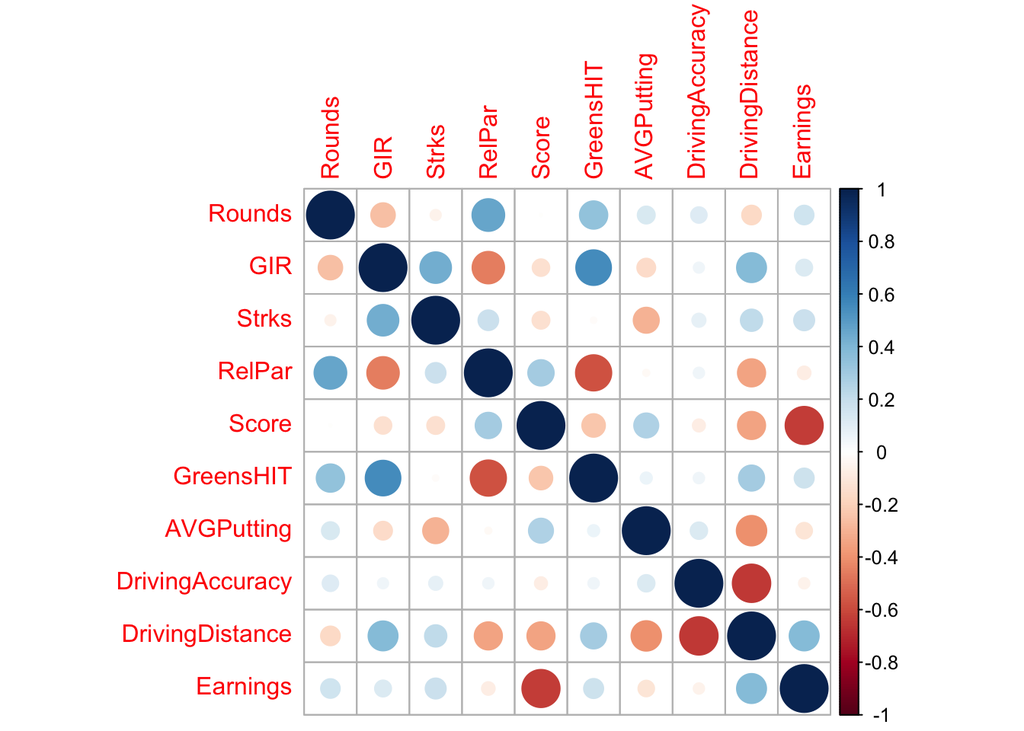

Figure 1: *In the picture above we can see the graphical representation of the correlation matrix, so stresses the relationship between the Earnings response variable and all other quantitative covariates, when we build the regression model then we will expect a high correlation with ScoreAVG and Driving Distance, which are identified by the circles with wider diameter and darker color*.

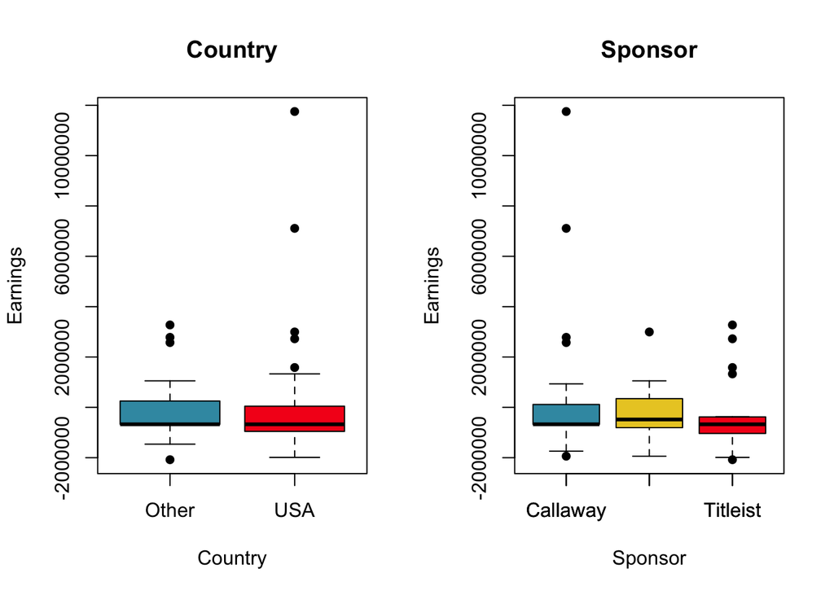

Figure 2.0

Figure 2.0 : *The figure shows the distribution of the qualitative variable Country, or the country of origin of the players, for the variable continuous response Earnings.Both levels have the same variability, but the “Other” level covers higher y values.Both lack symmetry with respect to the median, as we see the non-centrality of the black bar.For black dots outside the bar range, a high anomalous value of the Earnings variable belongs to the US level and a low anomalous value belongs to the Other level. In short, what he earned the most was American and what he earned the least was not*. Figure 2.1 : *As for the variable Sponsor character, which represents the brand that sponsors the players of PGATour, has three categories, from the left, Callaway, Taylormade, Titleist.We immediately realize that the three categories do not have the same variability, as Titleist has a much narrower bar than the other two, and Taylormade, has a much wider Titleist and little wider than Callaway.Titleist appears to be the only one symmetrical to the median, while the other two do not.While as for anomalous points, they are practically equidestribiti between Callaway and Titleist*.

#### Explaining my response

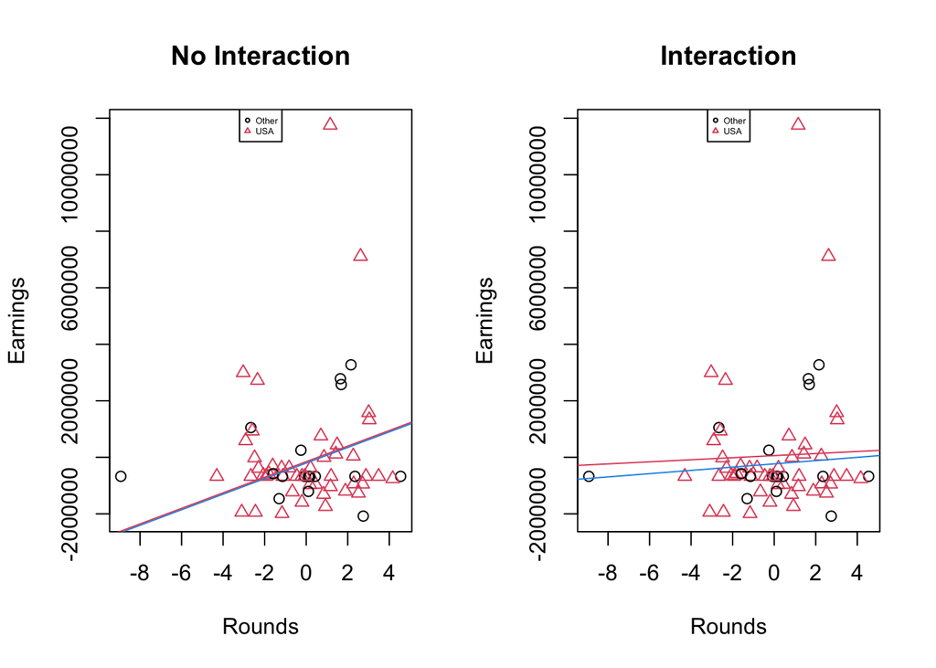

Figure 3 : *Comparison between model withouth interaction on Rounds*Country, on the leftside and with interaction on the rightside*.

#### Full linear model with interaction terms:

```
##                      Estimate  Std. Error    t value     Pr(>|t|)
## (Intercept)         387314.29  493107.702  0.7854558 4.359680e-01
## Rounds              195399.68  107107.766  1.8243278 7.420310e-02
## CountryUSA          114148.03  488591.096  0.2336269 8.162479e-01
## Strks               116776.72  855042.096  0.1365742 8.919269e-01
## ScoreAVG          -1869002.63  422854.205 -4.4199694 5.465853e-05
## SponsorTaylormade  -534244.27  503989.205 -1.0600312 2.943277e-01
## SponsorTitleist    -988994.98  519608.817 -1.9033453 6.287828e-02
## DrivAccuracy         59225.08   68685.481  0.8622649 3.927422e-01
## GIR                 272242.79  197930.891  1.3754437 1.752497e-01
## GreensHIT           -11834.58    7765.319 -1.5240296 1.339300e-01
## RelPar            -3141471.75 4104289.250 -0.7654119 4.476975e-01
## AVGPutting          604100.65  331411.310  1.8228124 7.443609e-02
## AVGDrivDistance     108547.35   47084.116  2.3053920 2.541928e-02
## Rounds:CountryUSA   -51072.74   63523.789 -0.8039939 4.252840e-01
```

From the summary of the coefficients of the model we can see the value of the intercept, or the expected value of the variable response Earnings, when all the independent variables in the model are zero or simply costant; while the coefficients associated with all the independent variables indicate the expected change in Earnings (y) for a unit change in the independent variables, keeping all other variables in the model constant. As for the qualitative variable Country, R has assigned as base level of the dummy, then value 0, to the category Other, for this in the output we see are Country:USA. In particular from a first screening we can see that the coefficients with the minus sign, represent an inverse relationship between the y and the x, that is ScoreAVG, Sponsor, GreensHIT, RelPar and the interaction term Rounds:CountryUSA, which indicates that the response will receive a decrease in absolute value of $ 51073 for an increase of one unit in Rounds, considering the USA group compared to the reference Other. Among these negative relationships it is worth pointing out the relationship between Earnings and GreensHIT, I certainly did not expect a negative value because logically a player more green takes more will have the ScoreAVG low and then will win more races. We will investigate this value later in our analysis.